# Case Study Solution by Nandini Saagar

## Question 1

As a decision maker, looking into these given booked accounts, how would you want to take a decision to approve/ decline the same applications again in future? What would be your screening criterion(s), if any?

## Explanation:

If a given person is credit worthy they must get their loan application approved and if the not, then get disapproved. Here are the relevant features that will be helpful in deciding the same:

- loan_amnt
- term
- installment
- emp_length
- home_ownership
- annual_income
- verification_status
- dti
- delinq_2yrs
- mths_since_last_delinq
- open_acc
- pub_rec
- revol_bal
- total_acc
- fico_score
- lti

## Question 2

Please provide data driven rationale to substantiate the appropriateness of the characteristics you have identified in the screening logic.

## Explanation:

To define the appropriateness of the features involved, Let's build various models using the following features and then evaluate and compare the accuracies of the models.

```python
import numpy as np
import pandas as pd
import matplotlib.pyplot as plt
import seaborn as sns
```

```python
df = pd.read_csv("loan_dataset_final.csv", encoding="ISO-8859-1")
df.head()
```

|  | id | member_id | loan_amnt | funded_amnt | funded_amnt_inv | term | installment | emp_title | emp_length | home_ownership | ... | collections_12_mths_ex_med | pub_rec_bankruptcies | interest_rate | revol_utilization | number_bc_gt_75 | fico_score | lti | month_since_oldest_tl | race_name | gender |
| --- | --- | --- | --- | --- | --- | --- | --- | --- | --- | --- | --- | --- | --- | --- | --- | --- | --- | --- | --- | --- | --- |
| 0 | 1000007 | 1225615 | 5150 | 5150 | 5150.0 | 60 months | 132.58 | atlantic tomorrows office | 1 year | RENT | ... | 0.0 | 1.0 | 0.1864 | 0.873 | 2 | 709 | 0.147176 | 124.0 | White | Female |
| 1 | 1000030 | 1225638 | 20000 | 20000 | 20000.0 | 36 months | 635.07 | The Red Threads Inc. | 6 years | RENT | ... | 0.0 | 0.0 | 0.0890 | 0.354 | 0 | 744 | 0.277778 | 149.0 | African American | Female |
| 2 | 1000033 | 1225642 | 12800 | 12800 | 12750.0 | 60 months | 316.54 | T-Mobile USA Inc | 9 years | MORTGAGE | ... | 0.0 | 0.0 | 0.1677 | 0.754 | 0 | 719 | 0.156655 | 176.0 | White | Female |
| 3 | 1000045 | 1225655 | 14000 | 14000 | 14000.0 | 60 months | 349.98 | Trader Joe's | 9 years | MORTGAGE | ... | 0.0 | 0.0 | 0.1727 | 0.357 | 0 | 714 | 0.194444 | 140.0 | White | Female |
| 4 | 1000067 | 1225680 | 15000 | 15000 | 14975.0 | 60 months | 370.94 | Truevance Engineering | < 1 year | RENT | ... | 0.0 | 0.0 | 0.1677 | 0.369 | 0 | 709 | 0.208333 | 136.0 | White | Female |

5 rows × 47 columns

Identifying the defaulters

```python
df["is_defaulter"] = df["loan_status"].apply(
    lambda x: 1 if x in ["Charged Off", "Default"] else 0
)
```

Here, a new column named `"is_defaulter"` is added to a DataFrame `df` based on the values in an existing column called `"loan_status"`.

The `apply` function is used to apply a function to each element in the `"loan_status"` column. In this case, the function is defined using a lambda expression.

**lambda x: 1 if x in ["Charged Off", "Default"] else 0** is the lambda function being applied to each element `x` in the `"loan_status"` column. The lambda function checks if the value of `x` is either `"Charged Off"` or `"Default"`.

- If `x` is either `"Charged Off"` or `"Default"`, the lambda function returns `1`.
- Otherwise, it returns `0`.

```python
df.head()
```

|  | id | member_id | loan_amnt | funded_amnt | funded_amnt_inv | term | installment | emp_title | emp_length | home_ownership | ... | pub_rec_bankruptcies | interest_rate | revol_utilization | number_bc_gt_75 | fico_score | lti | month_since_oldest_tl | race_name | gender | is_defaulter |
| --- | --- | --- | --- | --- | --- | --- | --- | --- | --- | --- | --- | --- | --- | --- | --- | --- | --- | --- | --- | --- | --- |
| 0 | 1000007 | 1225615 | 5150 | 5150 | 5150.0 | 60 months | 132.58 | atlantic tomorrows office | 1 year | RENT | ... | 1.0 | 0.1864 | 0.873 | 2 | 709 | 0.147176 | 124.0 | White | Female | 0 |
| 1 | 1000030 | 1225638 | 20000 | 20000 | 20000.0 | 36 months | 635.07 | The Red Threads Inc. | 6 years | RENT | ... | 0.0 | 0.0890 | 0.354 | 0 | 744 | 0.277778 | 149.0 | African American | Female | 0 |
| 2 | 1000033 | 1225642 | 12800 | 12800 | 12750.0 | 60 months | 316.54 | T-Mobile USA Inc | 9 years | MORTGAGE | ... | 0.0 | 0.1677 | 0.754 | 0 | 719 | 0.156655 | 176.0 | White | Female | 0 |
| 3 | 1000045 | 1225655 | 14000 | 14000 | 14000.0 | 60 months | 349.98 | Trader Joe's | 9 years | MORTGAGE | ... | 0.0 | 0.1727 | 0.357 | 0 | 714 | 0.194444 | 140.0 | White | Female | 0 |
| 4 | 1000067 | 1225680 | 15000 | 15000 | 14975.0 | 60 months | 370.94 | Truevance Engineering | < 1 year | RENT | ... | 0.0 | 0.1677 | 0.369 | 0 | 709 | 0.208333 | 136.0 | White | Female | 0 |

5 rows × 48 columns

### Performing Exploratory Data Analysis:

```python
df.info()
```

```
<class 'pandas.core.frame.DataFrame'>
RangeIndex: 42535 entries, 0 to 42534
Data columns (total 48 columns):
 #   Column                      Non-Null Count  Dtype
---  ------                      --------------  -----
 0   id                          42535 non-null  int64
 1   member_id                   42535 non-null  int64
 2   loan_amnt                   42535 non-null  int64
 3   funded_amnt                 42535 non-null  int64
 4   funded_amnt_inv             42535 non-null  float64
 5   term                        42535 non-null  object
 6   installment                 42535 non-null  float64
 7   emp_title                   39909 non-null  object
 8   emp_length                  41423 non-null  object
 9   home_ownership              42535 non-null  object
```

[output cut: 40 more lines]

```python
df.describe()
```

|  | id | member_id | loan_amnt | funded_amnt | funded_amnt_inv | installment | annual_inc | dti | delinq_2yrs | inq_last_6mths | ... | collection_recovery_fee | collections_12_mths_ex_med | pub_rec_bankruptcies | interest_rate | revol_utilization | number_bc_gt_75 | fico_score | lti | month_since_oldest_tl | is_defaulter |
| --- | --- | --- | --- | --- | --- | --- | --- | --- | --- | --- | --- | --- | --- | --- | --- | --- | --- | --- | --- | --- | --- |
| count | 4.253500e+04 | 4.253500e+04 | 42535.000000 | 42535.000000 | 42535.000000 | 42535.000000 | 4.253100e+04 | 42535.000000 | 42506.000000 | 42506.000000 | ... | 42535.000000 | 42390.0 | 41170.000000 | 42535.000000 | 42445.000000 | 42535.000000 | 42535.000000 | 42531.000000 | 42506.000000 | 42535.000000 |
| mean | 6.645799e+05 | 8.257026e+05 | 11089.722581 | 10821.585753 | 10139.830603 | 322.623063 | 6.913656e+04 | 13.373043 | 0.152449 | 1.306357 | ... | 13.956737 | 0.0 | 0.045227 | 0.121650 | 0.442584 | 0.499988 | 723.065240 | 0.186105 | 107.567073 | 0.132926 |
| std | 2.193022e+05 | 2.795409e+05 | 7410.938391 | 7146.914675 | 7131.686447 | 208.927216 | 6.409635e+04 | 6.726315 | 0.512406 | 1.711415 | ... | 159.621861 | 0.0 | 0.208737 | 0.037079 | 0.306107 | 0.785378 | 30.241456 | 0.116228 | 58.874550 | 0.339499 |
| min | 5.473400e+04 | 7.047300e+04 | 500.000000 | 500.000000 | 0.000000 | 15.670000 | 1.896000e+03 | 0.000000 | 0.000000 | 0.000000 | ... | 0.000000 | 0.0 | 0.000000 | 0.054200 | 0.000000 | 0.000000 | 619.000000 | 0.000789 | 1.000000 | 0.000000 |
| 25% | 4.983925e+05 | 6.384795e+05 | 5200.000000 | 5000.000000 | 4950.000000 | 165.520000 | 4.000000e+04 | 8.200000 | 0.000000 | 0.000000 | ... | 0.000000 | 0.0 | 0.000000 | 0.096300 | 0.166000 | 0.000000 | 704.000000 | 0.097674 | 67.000000 | 0.000000 |
| 50% | 6.442500e+05 | 8.241780e+05 | 9700.000000 | 9600.000000 | 8500.000000 | 277.690000 | 5.900000e+04 | 13.470000 | 0.000000 | 1.000000 | ... | 0.000000 | 0.0 | 0.000000 | 0.119900 | 0.446000 | 0.000000 | 719.000000 | 0.162813 | 98.000000 | 0.000000 |
| 75% | 8.258225e+05 | 1.033946e+06 | 15000.000000 | 15000.000000 | 14000.000000 | 428.180000 | 8.250000e+04 | 18.680000 | 0.000000 | 2.000000 | ... | 0.000000 | 0.0 | 0.000000 | 0.147200 | 0.701000 | 1.000000 | 739.000000 | 0.250000 | 134.000000 | 0.000000 |
| max | 1.077501e+06 | 1.314167e+06 | 35000.000000 | 35000.000000 | 35000.000000 | 1305.190000 | 6.000000e+06 | 29.990000 | 13.000000 | 33.000000 | ... | 7002.190000 | 0.0 | 2.000000 | 0.245900 | 1.088000 | 3.000000 | 829.000000 | 1.337500 | 685.000000 | 1.000000 |

8 rows × 34 columns

```python
df['is_defaulter'].value_counts()
```

```
is_defaulter
0    36881
1     5654
Name: count, dtype: int64
```

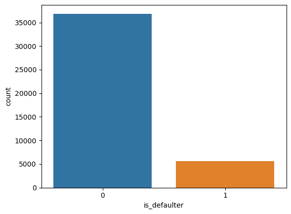

```python
sns.countplot(data=df,x='is_defaulter')
```

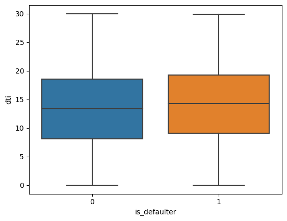

```python
sns.boxplot(x='is_defaulter',y='dti',data=df)
```

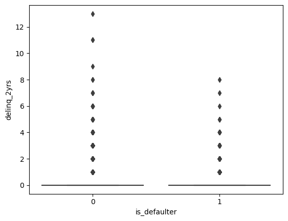

```python
sns.boxplot(x='is_defaulter',y='delinq_2yrs',data=df)
```

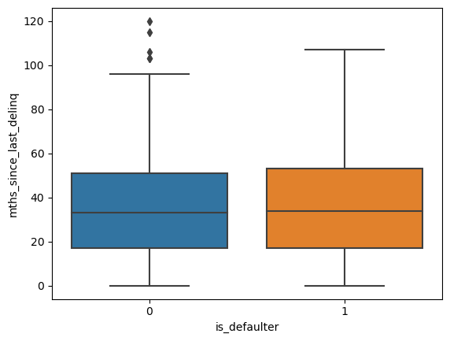

```python
sns.boxplot(
    x='is_defaulter',
    y='mths_since_last_delinq',
    data=df
)
```

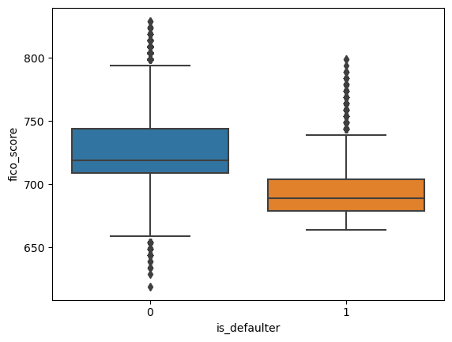

```python
sns.boxplot(
    x='is_defaulter',
    y='fico_score',
    data=df
)
```

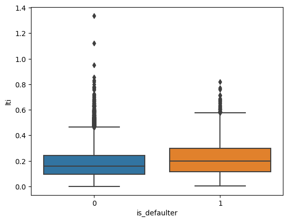

```python
sns.boxplot(
    x='is_defaulter',
    y='lti',
    data=df
)
```

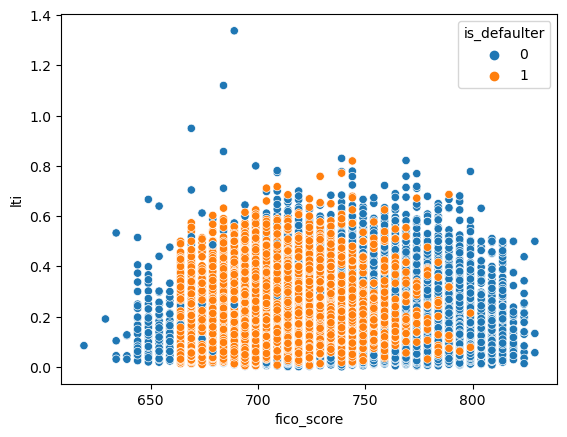

```python
sns.scatterplot(
    x='fico_score',
    y='lti',
    data=df,
    hue='is_defaulter'
)
```

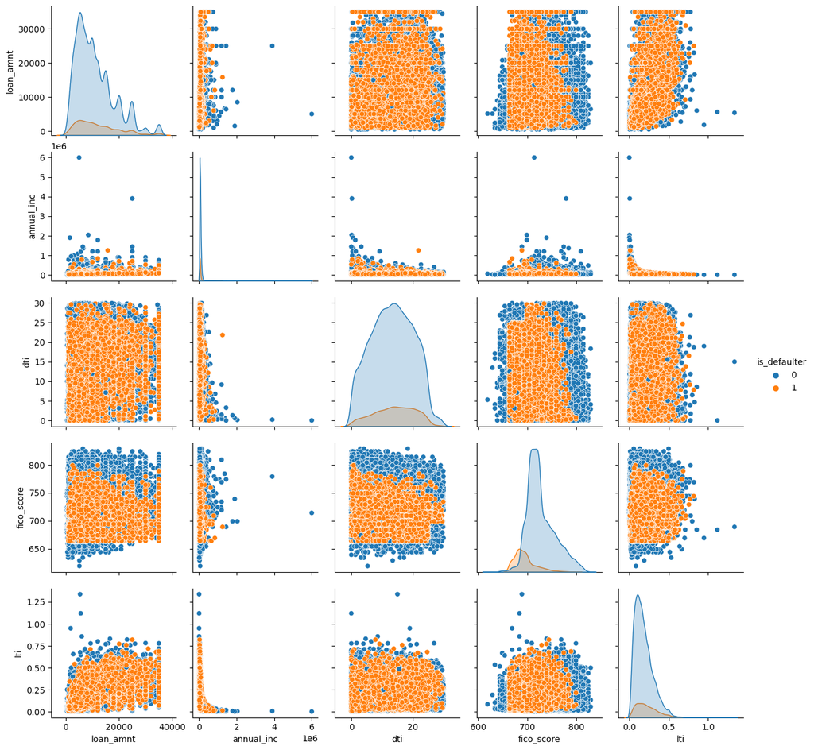

```python
sns.pairplot(
    df[[
        'loan_amnt',
        'annual_inc',
        'dti',
        'fico_score',
        'lti',
        'is_defaulter'
    ]],
    hue='is_defaulter'
)
```

### Encoding Categorical Features:

Here, the categorical features are encoded using the `LabelEncoder` class from the `sklearn.preprocessing` module. The `LabelEncoder` class is used to encode categorical features as integers.

In addition to the same, we handle the special columns which do not have any numerical values and convert them into numerical values.

1. **Processing the "term" column**:
   - It converts "term" values like "36 months" or "60 months" to integers 36 and 60 by splitting the string at spaces and taking the first part.
2. **Defining and applying `parse_emp_length`**:
   - It defines a function `parse_emp_length` to handle different formats in the "emp_length" column:
     - If the value is a float (e.g., `NaN`), it returns the value as is.
     - It strips any leading or trailing spaces from the string.
     - It converts "< 1 year" to 0.5 and "10+ years" to 10.
     - For other values like "3 years", it splits the string and takes the first part, converting it to an integer.
   - This function is applied to the "emp_length" column, standardizing the values into numerical format.

```python
# Encoding categorical features
from sklearn.preprocessing import LabelEncoder

for feature in [
    "home_ownership",
    "verification_status",
]:
    le = LabelEncoder()
    df[feature] = le.fit_transform(df[feature])

# Handle specifc columns with special format data
df["term"] = df["term"].apply(lambda x: int(x.split()[0]))


def parse_emp_length(x):
    if type(x) == float:
        return x
    x = x.strip(" ")
    if x == "< 1 year":
        return 0.5

    if x == "10+ years":
        return 10

    return int(x.split()[0])


df["emp_length"] = df["emp_length"].apply(parse_emp_length)

df.head()
```

|  | id | member_id | loan_amnt | funded_amnt | funded_amnt_inv | term | installment | emp_title | emp_length | home_ownership | ... | pub_rec_bankruptcies | interest_rate | revol_utilization | number_bc_gt_75 | fico_score | lti | month_since_oldest_tl | race_name | gender | is_defaulter |
| --- | --- | --- | --- | --- | --- | --- | --- | --- | --- | --- | --- | --- | --- | --- | --- | --- | --- | --- | --- | --- | --- |
| 0 | 1000007 | 1225615 | 5150 | 5150 | 5150.0 | 60 | 132.58 | atlantic tomorrows office | 1.0 | 4 | ... | 1.0 | 0.1864 | 0.873 | 2 | 709 | 0.147176 | 124.0 | White | Female | 0 |
| 1 | 1000030 | 1225638 | 20000 | 20000 | 20000.0 | 36 | 635.07 | The Red Threads Inc. | 6.0 | 4 | ... | 0.0 | 0.0890 | 0.354 | 0 | 744 | 0.277778 | 149.0 | African American | Female | 0 |
| 2 | 1000033 | 1225642 | 12800 | 12800 | 12750.0 | 60 | 316.54 | T-Mobile USA Inc | 9.0 | 0 | ... | 0.0 | 0.1677 | 0.754 | 0 | 719 | 0.156655 | 176.0 | White | Female | 0 |
| 3 | 1000045 | 1225655 | 14000 | 14000 | 14000.0 | 60 | 349.98 | Trader Joe's | 9.0 | 0 | ... | 0.0 | 0.1727 | 0.357 | 0 | 714 | 0.194444 | 140.0 | White | Female | 0 |
| 4 | 1000067 | 1225680 | 15000 | 15000 | 14975.0 | 60 | 370.94 | Truevance Engineering | 0.5 | 4 | ... | 0.0 | 0.1677 | 0.369 | 0 | 709 | 0.208333 | 136.0 | White | Female | 0 |

5 rows × 48 columns

While selecting features, we keep the following points in mind:

- All these features must be available at the time of application
- They should ideally do not contain any personally identifiable information, so that the model does not pose any privacy risks
- Attributes like race, gender, age, etc. should not be used as they can lead to biased predictions
- These features should alteast loosely correlate with the target variable and financial health of the applicant, as dedicated by common sense and notion.

After the same, we also remove the columns with a number of `NaN` values, and fill the rest with the mean of the column. This is done to ensure that the model does not have any missing values.

```python
features = [
    "loan_amnt",
    "term",
    "installment",
    "emp_length",
    "home_ownership",
    "annual_inc",
    "verification_status",
    "dti",
    "delinq_2yrs",
    "inq_last_6mths",
    "mths_since_last_delinq",
    "open_acc",
    "pub_rec",
    "revol_bal",
    "total_acc",
    "fico_score",
    "lti",
]

# Remove mnths_since_last_delinq and emp_length columns as they have a lot of NaN values
features.remove("mths_since_last_delinq")
features.remove("emp_length")

# Fill NaN values with the mean of the column
for feature in features:
    df.iloc[:, df.columns.get_loc(feature)] = df[feature].fillna(df[feature].mean())

df = df[features + ["is_defaulter"]]
df.head()
```

|  | loan_amnt | term | installment | home_ownership | annual_inc | verification_status | dti | delinq_2yrs | inq_last_6mths | open_acc | pub_rec | revol_bal | total_acc | fico_score | lti | is_defaulter |
| --- | --- | --- | --- | --- | --- | --- | --- | --- | --- | --- | --- | --- | --- | --- | --- | --- |
| 0 | 5150 | 60 | 132.58 | 4 | 34992.0 | 1 | 17.59 | 0.0 | 3.0 | 15.0 | 1.0 | 15187 | 21.0 | 709 | 0.147176 | 0 |
| 1 | 20000 | 36 | 635.07 | 4 | 72000.0 | 2 | 7.80 | 0.0 | 2.0 | 6.0 | 0.0 | 15637 | 14.0 | 744 | 0.277778 | 0 |
| 2 | 12800 | 60 | 316.54 | 0 | 81708.0 | 1 | 14.22 | 1.0 | 1.0 | 7.0 | 0.0 | 905 | 23.0 | 719 | 0.156655 | 0 |
| 3 | 14000 | 60 | 349.98 | 0 | 72000.0 | 2 | 20.35 | 0.0 | 1.0 | 16.0 | 0.0 | 9218 | 39.0 | 714 | 0.194444 | 0 |
| 4 | 15000 | 60 | 370.94 | 4 | 72000.0 | 2 | 20.50 | 0.0 | 0.0 | 12.0 | 0.0 | 10891 | 30.0 | 709 | 0.208333 | 0 |

#### Prepare the Data for Training

```python
X = df.drop('is_defaulter',axis=1)
y = df['is_defaulter']
```

```python
from sklearn.model_selection import train_test_split
from sklearn.preprocessing import StandardScaler

X_train, X_test, y_train, y_test = train_test_split(
    X, y, test_size=0.1
)

scaler = StandardScaler()

scaled_X_train = scaler.fit_transform(X_train)
scaled_X_test = scaler.transform(X_test)
```

### Logistic Regression Model

```python
from sklearn.linear_model import LogisticRegression

log_model = LogisticRegression()
log_model.fit(scaled_X_train, y_train)
```

```
LogisticRegression()
```

```python
log_model.coef_
```

```
array([[ 0.8466957 ,  0.12428815, -0.82952042, -0.03614688, -0.06289597,
         0.09657995, -0.12918231, -0.20017166,  0.39097567, -0.17862258,
        -0.06189653, -0.05227772,  0.17617472, -1.93008062,  0.34631879]])
```

#### Performance

```python
from sklearn.metrics import accuracy_score,classification_report

y_pred = log_model.predict(scaled_X_test)
accuracy_score(y_test, y_pred)
```

```
0.8930418429713212
```

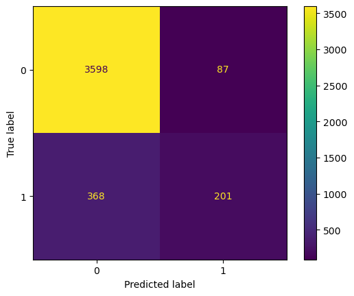

```python
from sklearn.metrics import confusion_matrix, ConfusionMatrixDisplay

cm = confusion_matrix(y_test,y_pred)
disp = ConfusionMatrixDisplay(confusion_matrix=cm)
disp.plot()
plt.show()
```

```python
print(classification_report(y_test,y_pred))
```

```
              precision    recall  f1-score   support

           0       0.91      0.98      0.94      3685
           1       0.70      0.35      0.47       569

    accuracy                           0.89      4254
   macro avg       0.80      0.66      0.70      4254
weighted avg       0.88      0.89      0.88      4254
```

#### Model Accuracy

89%

#### Evaluating Curves and AUC

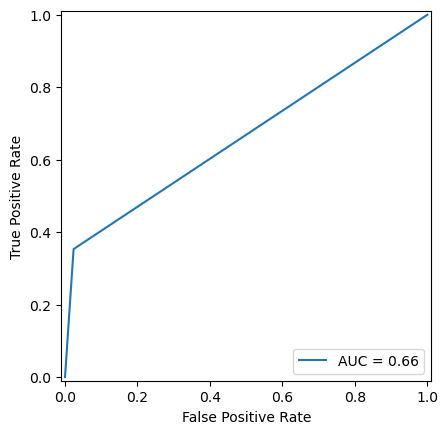

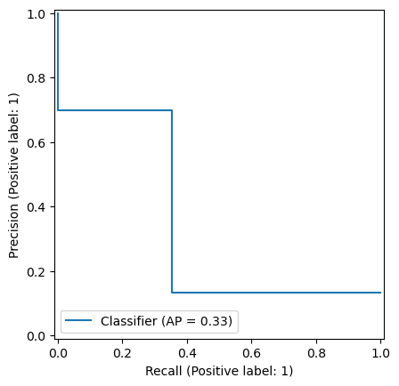

```python
from sklearn.metrics import PrecisionRecallDisplay
from sklearn import metrics

fpr, tpr, thresholds = metrics.roc_curve(y_test, y_pred)

roc_auc = metrics.auc(fpr, tpr)
display = metrics.RocCurveDisplay(fpr=fpr, tpr=tpr, roc_auc=roc_auc)
display.plot()
plt.show()

PrecisionRecallDisplay.from_predictions(y_test, y_pred)
plt.show()
```

### Decision Tree Classifier

```python
from sklearn.tree import DecisionTreeClassifier

model = DecisionTreeClassifier()
model.fit(X_train, y_train)
```

```
DecisionTreeClassifier()
```

```
[[3408  277]
 [ 218  351]]
```

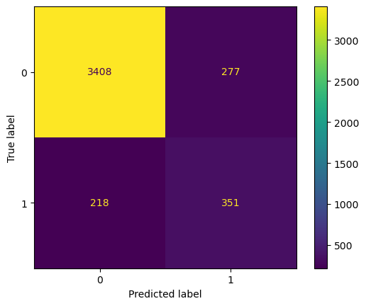

```python
base_pred = model.predict(X_test)
print(confusion_matrix(y_test, base_pred))

cm = confusion_matrix(y_test, base_pred)
disp = ConfusionMatrixDisplay(confusion_matrix=cm)
disp.plot()
plt.show()
```

```python
print(classification_report(y_test,base_pred))
```

```
              precision    recall  f1-score   support

           0       0.94      0.92      0.93      3685
           1       0.56      0.62      0.59       569

    accuracy                           0.88      4254
   macro avg       0.75      0.77      0.76      4254
weighted avg       0.89      0.88      0.89      4254
```

#### Model Accuracy

88%

```python
model.feature_importances_
```

```
array([0.03380809, 0.01203519, 0.07125944, 0.01148217, 0.05051299,
       0.01777959, 0.07939944, 0.00651266, 0.10958668, 0.03386672,
       0.0048568 , 0.07596503, 0.04619592, 0.36237202, 0.08436725])
```

```python
pd.DataFrame(
    index=X.columns,
    data=model.feature_importances_,
    columns=['Feature Importance']
).sort_values(
    'Feature Importance',
    ascending=False,
    inplace=True
)
```

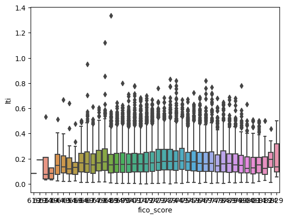

```python
sns.boxplot(x='fico_score',y='lti',data=df)
```

### Random Forest Classifier

```python
from sklearn.ensemble import RandomForestClassifier

# Use 10 random trees
model = RandomForestClassifier(n_estimators=10)
model.fit(X_train, y_train)
```

```
RandomForestClassifier(n_estimators=10)
```

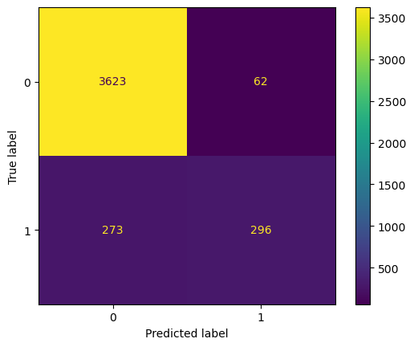

```python
base_pred = model.predict(X_test)

#  Plot the confusion matrix
cm = confusion_matrix(y_test, base_pred)
disp = ConfusionMatrixDisplay(confusion_matrix=cm)
disp.plot()
plt.show()
```

```python
print(classification_report(y_test, base_pred))
```

```
              precision    recall  f1-score   support

           0       0.93      0.98      0.96      3685
           1       0.83      0.52      0.64       569

    accuracy                           0.92      4254
   macro avg       0.88      0.75      0.80      4254
weighted avg       0.92      0.92      0.91      4254
```

### Model Accuarcy

92%

```python
model.feature_importances_
```

```
array([0.05017686, 0.02063   , 0.06817122, 0.01269615, 0.06348725,
       0.01818864, 0.06878396, 0.01016184, 0.14855666, 0.04503741,
       0.00443753, 0.07022704, 0.05319116, 0.29134898, 0.07490531])
```

```python
feat_imp = pd.DataFrame(
    index=X.columns,
    data=model.feature_importances_,
    columns=["Feature Importance"]
)
feat_imp.sort_values(by="Feature Importance", ascending=False, inplace=True)
feat_imp
```

|  | Feature Importance |
| --- | --- |
| fico_score | 0.291349 |
| inq_last_6mths | 0.148557 |
| lti | 0.074905 |
| revol_bal | 0.070227 |
| dti | 0.068784 |
| installment | 0.068171 |
| annual_inc | 0.063487 |
| total_acc | 0.053191 |
| loan_amnt | 0.050177 |
| open_acc | 0.045037 |
| term | 0.020630 |
| verification_status | 0.018189 |
| home_ownership | 0.012696 |
| delinq_2yrs | 0.010162 |
| pub_rec | 0.004438 |

## Comparing Model Accuracies

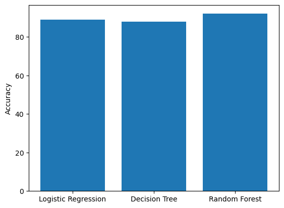

```python
data = {
    "Logistic Regression": 89,
    "Decision Tree": 88,
    "Random Forest": 92,
}
plt.bar(data.keys(), data.values())
plt.ylabel("Accuracy")
plt.show()
```

# Question 3

Given that you have a decision engine, which helps you to take a call based on the given data, how would you identify if your process has an unintentional bias and discriminate your customers based on some of the sensitive attributes, available in this dataset?

## Explanation:

As an experiment, we can also train the model on the features like `race` and `gender` and see how much the same influences the model.

```python
# Reload the dataset from scratch
df = pd.read_csv("loan_dataset_final.csv", encoding="ISO-8859-1")

df["is_defaulter"] = df["loan_status"].apply(
    lambda x: 1 if x in ["Charged Off", "Default"] else 0
)
df["term"] = df["term"].apply(lambda x: int(x.split()[0]))
df["emp_length"] = df["emp_length"].apply(parse_emp_length)
for feature in ["home_ownership", "verification_status", "race_name", "gender"]:
    le = LabelEncoder()
    df[feature] = le.fit_transform(df[feature])

df.head()
```

|  | id | member_id | loan_amnt | funded_amnt | funded_amnt_inv | term | installment | emp_title | emp_length | home_ownership | ... | pub_rec_bankruptcies | interest_rate | revol_utilization | number_bc_gt_75 | fico_score | lti | month_since_oldest_tl | race_name | gender | is_defaulter |
| --- | --- | --- | --- | --- | --- | --- | --- | --- | --- | --- | --- | --- | --- | --- | --- | --- | --- | --- | --- | --- | --- |
| 0 | 1000007 | 1225615 | 5150 | 5150 | 5150.0 | 60 | 132.58 | atlantic tomorrows office | 1.0 | 4 | ... | 1.0 | 0.1864 | 0.873 | 2 | 709 | 0.147176 | 124.0 | 3 | 0 | 0 |
| 1 | 1000030 | 1225638 | 20000 | 20000 | 20000.0 | 36 | 635.07 | The Red Threads Inc. | 6.0 | 4 | ... | 0.0 | 0.0890 | 0.354 | 0 | 744 | 0.277778 | 149.0 | 0 | 0 | 0 |
| 2 | 1000033 | 1225642 | 12800 | 12800 | 12750.0 | 60 | 316.54 | T-Mobile USA Inc | 9.0 | 0 | ... | 0.0 | 0.1677 | 0.754 | 0 | 719 | 0.156655 | 176.0 | 3 | 0 | 0 |
| 3 | 1000045 | 1225655 | 14000 | 14000 | 14000.0 | 60 | 349.98 | Trader Joe's | 9.0 | 0 | ... | 0.0 | 0.1727 | 0.357 | 0 | 714 | 0.194444 | 140.0 | 3 | 0 | 0 |
| 4 | 1000067 | 1225680 | 15000 | 15000 | 14975.0 | 60 | 370.94 | Truevance Engineering | 0.5 | 4 | ... | 0.0 | 0.1677 | 0.369 | 0 | 709 | 0.208333 | 136.0 | 3 | 0 | 0 |

5 rows × 48 columns

```python
unbiased_features = [
    "loan_amnt",
    "term",
    "installment",
    "home_ownership",
    "annual_inc",
    "verification_status",
    "dti",
    "delinq_2yrs",
    "inq_last_6mths",
    "open_acc",
    "pub_rec",
    "revol_bal",
    "total_acc",
    "fico_score",
    "lti",
]
biased_features = unbiased_features + ["race_name", "gender"]

all_features = biased_features + ["is_defaulter"]
df = df[all_features].fillna(df[all_features].mean())

df.head()
```

|  | loan_amnt | term | installment | home_ownership | annual_inc | verification_status | dti | delinq_2yrs | inq_last_6mths | open_acc | pub_rec | revol_bal | total_acc | fico_score | lti | race_name | gender | is_defaulter |
| --- | --- | --- | --- | --- | --- | --- | --- | --- | --- | --- | --- | --- | --- | --- | --- | --- | --- | --- |
| 0 | 5150 | 60 | 132.58 | 4 | 34992.0 | 1 | 17.59 | 0.0 | 3.0 | 15.0 | 1.0 | 15187 | 21.0 | 709 | 0.147176 | 3 | 0 | 0 |
| 1 | 20000 | 36 | 635.07 | 4 | 72000.0 | 2 | 7.80 | 0.0 | 2.0 | 6.0 | 0.0 | 15637 | 14.0 | 744 | 0.277778 | 0 | 0 | 0 |
| 2 | 12800 | 60 | 316.54 | 0 | 81708.0 | 1 | 14.22 | 1.0 | 1.0 | 7.0 | 0.0 | 905 | 23.0 | 719 | 0.156655 | 3 | 0 | 0 |
| 3 | 14000 | 60 | 349.98 | 0 | 72000.0 | 2 | 20.35 | 0.0 | 1.0 | 16.0 | 0.0 | 9218 | 39.0 | 714 | 0.194444 | 3 | 0 | 0 |
| 4 | 15000 | 60 | 370.94 | 4 | 72000.0 | 2 | 20.50 | 0.0 | 0.0 | 12.0 | 0.0 | 10891 | 30.0 | 709 | 0.208333 | 3 | 0 | 0 |

```python
df_train, df_test = train_test_split(df, test_size=0.2)

# Train the model with unbiased features and get the accuracy
x_unbiased_train = df_train[unbiased_features]
y_unbiased_train = df_train["is_defaulter"]

x_unbiased_test = df_test[unbiased_features]
y_unbiased_test = df_test["is_defaulter"]

model = RandomForestClassifier(n_estimators=10)
model.fit(x_unbiased_train, y_unbiased_train)

y_unbiased_pred = model.predict(x_unbiased_test)
accuracy_score(y_unbiased_test, y_unbiased_pred)
```

```
0.9187727753614671
```

```python
# Train the model with biased features and get the accuracy
x_biased_train = df_train[biased_features]
y_biased_train = df_train["is_defaulter"]

x_biased_test = df_test[biased_features]
y_biased_test = df_test["is_defaulter"]

model = RandomForestClassifier(n_estimators=10)
model.fit(x_biased_train, y_biased_train)

y_biased_pred = model.predict(x_biased_test)
accuracy_score(y_biased_test, y_biased_pred)
```

```
0.9173621723286705
```

```python
biased_index = y_biased_pred != y_biased_test
biased_entries = df_test[biased_index]

print(f"Biased predictions: {len(biased_entries)/len(df_test)*100:.2f}%")
```

```
Biased predictions: 8.26%
```

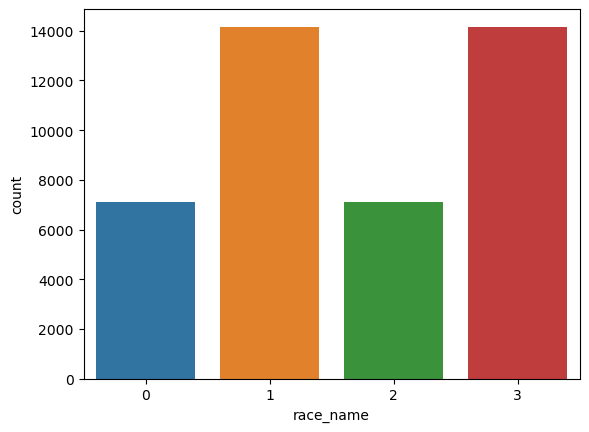

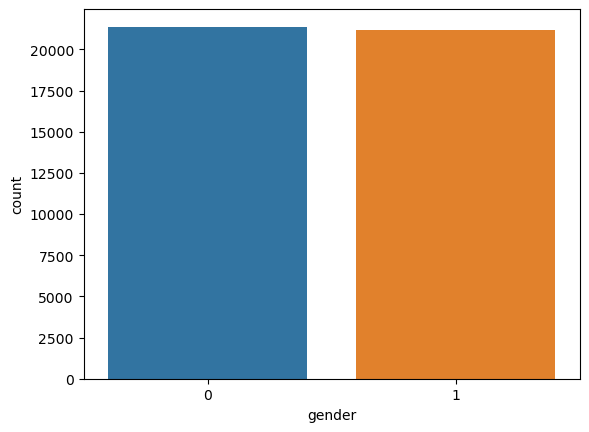

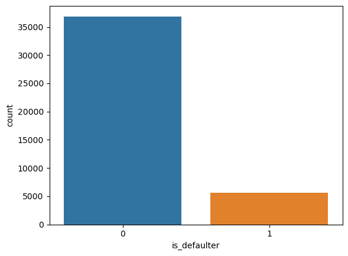

```python
# Plot the frequency of the race_name, gender and is_defaulter columns
for col in ["race_name", "gender", "is_defaulter"]:
    sns.countplot(data=df, x=col)
    plt.show()
```

### Further Improvements that can be implemented in the Model

While these runs give a baseline of the model that can be used for predictions, there are many further ideas that can be implemented to improve the model accuracy and performance.

Some of them that I would like to explore as future scope include:

- Moving from `Accuracy` to `F1 Score` as the target metric due to the skewed nature of the dataset
- Using `GridSearchCV` to find the best hyperparameters for the models
- Using a bitmask over all the features to find the best features for the model